# Восстановление золота из руды

Требуется подготовить прототип модели машинного обучения для «Цифры». Компания разрабатывает решения для эффективной работы промышленных предприятий.

Модель должна предсказать коэффициент восстановления золота из золотосодержащей руды.

Модель поможет оптимизировать производство, чтобы не запускать предприятие с убыточными характеристиками.

```python
from IPython.display import display, HTML
display(HTML("<style>.container { width:90% !important; }</style>"))
```

## Подготовка данных

```python
import pandas as pd
from sklearn.metrics import mean_absolute_error
import numpy as np
import matplotlib.pyplot as plt
from sklearn.preprocessing import StandardScaler
from sklearn.tree import DecisionTreeRegressor
from sklearn.ensemble import RandomForestRegressor
from sklearn.linear_model import LinearRegression
from sklearn.model_selection import GridSearchCV
from sklearn.metrics import make_scorer
import os
import seaborn as sns
from sklearn.dummy import DummyRegressor
```

```python
np.random.seed(12345) #Фиксация псевдослучайности
```

```python
file_path1 = 'gold_industry_train.csv'
file_path2 = 'gold_industry_test.csv'
file_path3 = 'gold_industry_full.csv'

if os.path.exists(file_path1):
    df_t = pd.read_csv(file_path1, parse_dates=['date'], index_col='date')
else:
    print(f"File not found: {file_path1}")

if os.path.exists(file_path2):
    df_te = pd.read_csv(file_path2, parse_dates=['date'], index_col='date')
else:
    print(f"File not found: {file_path2}")

if os.path.exists(file_path3):
    df_f = pd.read_csv(file_path3, parse_dates=['date'], index_col='date')
else:
    print(f"File not found: {file_path3}")
```

```python
def explore_data(df):
    print("Первые 5 строк набора данных:")
    display(df.head())

    print("\nИнформация о наборе данных:")
    display(df.info())

    print("\nСтатистические характеристики числовых столбцов:")
    display(df.describe(include='all').T)

    print("\nЧисло уникальных значений в каждом столбце:")
    for column in df.columns:
        unique_values = df[column].unique()
        num_unique_values = len(unique_values)
        print(f"Столбец '{column}' содержит {num_unique_values} уникальных значений.")

    print("\nЧисло значений по категориям в каждом столбце:")
    for column in df.columns:
        if df[column].dtype == 'object':
            value_counts = df[column].value_counts()
            print(f"Столбец '{column}':")
            print(value_counts)

    print("\nГистограммы всех числовых столбцов:")
    df.hist(figsize=(25, 25))
```

### Общее представление о наборе данных

```
Первые 5 строк набора данных:
```

| date | rougher.input.feed_au | rougher.input.feed_ag | rougher.input.feed_pb | rougher.input.feed_sol | rougher.input.feed_rate | rougher.input.feed_size | rougher.input.floatbank10_sulfate | rougher.input.floatbank10_xanthate | rougher.state.floatbank10_a_air | rougher.state.floatbank10_a_level | ... | secondary_cleaner.output.tail_sol | final.output.concentrate_au | final.output.concentrate_ag | final.output.concentrate_pb | final.output.concentrate_sol | final.output.recovery | final.output.tail_au | final.output.tail_ag | final.output.tail_pb | final.output.tail_sol |
| --- | --- | --- | --- | --- | --- | --- | --- | --- | --- | --- | --- | --- | --- | --- | --- | --- | --- | --- | --- | --- | --- |
| 2016-01-15 00:00:00 | 6.486150 | 6.100378 | 2.284912 | 36.808594 | 523.546326 | 55.486599 | 11.986616 | 6.007990 | 999.706909 | -404.066986 | ... | 8.764648 | 42.192020 | 6.055403 | 9.889648 | 5.507324 | 70.541216 | 2.143149 | 10.411962 | 0.895447 | 16.904297 |
| 2016-01-15 01:00:00 | 6.478583 | 6.161113 | 2.266033 | 35.753385 | 525.290581 | 57.278666 | 11.971193 | 6.005766 | 1000.286398 | -400.065196 | ... | 9.001494 | 42.701629 | 6.029369 | 9.968944 | 5.257781 | 69.266198 | 2.224930 | 10.462676 | 0.927452 | 16.634514 |
| 2016-01-15 02:00:00 | 6.362222 | 6.116455 | 2.159622 | 35.971630 | 530.026610 | 57.510649 | 11.920603 | 6.197377 | 999.719565 | -400.074028 | ... | 8.842896 | 42.657501 | 6.055926 | 10.213995 | 5.383759 | 68.116445 | 2.257889 | 10.507046 | 0.953716 | 16.208849 |
| 2016-01-15 03:00:00 | 6.118189 | 6.043309 | 2.037807 | 36.862241 | 542.590390 | 57.792734 | 11.630094 | 6.203177 | 999.814770 | -400.200179 | ... | 9.122857 | 42.689819 | 6.047977 | 9.977019 | 4.858634 | 68.347543 | 2.146849 | 10.422762 | 0.883763 | 16.532835 |
| 2016-01-15 04:00:00 | 5.663707 | 6.060915 | 1.786875 | 34.347666 | 540.531893 | 56.047189 | 10.957755 | 6.198826 | 999.678690 | -399.752729 | ... | 8.871028 | 42.774141 | 6.148599 | 10.142511 | 4.939416 | 66.927016 | 2.055292 | 10.360302 | 0.792826 | 16.525686 |

5 rows × 86 columns

```
Информация о наборе данных:
<class 'pandas.core.frame.DataFrame'>
DatetimeIndex: 14579 entries, 2016-01-15 00:00:00 to 2017-12-09 13:59:59
Data columns (total 86 columns):
 #   Column                                              Non-Null Count  Dtype
---  ------                                              --------------  -----
 0   rougher.input.feed_au                               14579 non-null  float64
 1   rougher.input.feed_ag                               14579 non-null  float64
 2   rougher.input.feed_pb                               14507 non-null  float64
 3   rougher.input.feed_sol                              14502 non-null  float64
 4   rougher.input.feed_rate                             14572 non-null  float64
 5   rougher.input.feed_size                             14478 non-null  float64
 6   rougher.input.floatbank10_sulfate                   14548 non-null  float64
 7   rougher.input.floatbank10_xanthate                  14572 non-null  float64
 8   rougher.state.floatbank10_a_air                     14579 non-null  float64
```

[output cut: 79 more lines]

```
None
```

```
Статистические характеристики числовых столбцов:
```

|  | count | mean | std | min | 25% | 50% | 75% | max |
| --- | --- | --- | --- | --- | --- | --- | --- | --- |
| rougher.input.feed_au | 14579.0 | 8.352941 | 1.934376 | 0.010000 | 6.932996 | 8.225284 | 9.832210 | 13.731330 |
| rougher.input.feed_ag | 14579.0 | 8.877460 | 1.922536 | 0.010000 | 7.341922 | 8.715859 | 10.255843 | 14.596026 |
| rougher.input.feed_pb | 14507.0 | 3.604221 | 1.056063 | 0.010000 | 2.880490 | 3.532399 | 4.257282 | 7.052325 |
| rougher.input.feed_sol | 14502.0 | 36.561420 | 5.209823 | 0.010000 | 34.093951 | 37.097511 | 39.899799 | 53.475325 |
| rougher.input.feed_rate | 14572.0 | 474.332784 | 108.503552 | 0.002986 | 411.048483 | 498.187968 | 549.586552 | 717.508837 |
| ... | ... | ... | ... | ... | ... | ... | ... | ... |
| final.output.recovery | 14579.0 | 66.759066 | 10.619709 | 0.000000 | 63.114596 | 67.962788 | 72.598187 | 100.000000 |
| final.output.tail_au | 14579.0 | 3.087939 | 0.915187 | 0.000000 | 2.505287 | 3.029238 | 3.614098 | 8.245022 |
| final.output.tail_ag | 14578.0 | 9.731972 | 2.358143 | 0.000000 | 8.088928 | 9.818512 | 11.169187 | 19.552149 |
| final.output.tail_pb | 14504.0 | 2.719985 | 0.958929 | 0.000000 | 2.036512 | 2.774847 | 3.353845 | 5.804178 |
| final.output.tail_sol | 14574.0 | 10.612745 | 2.871075 | 0.000000 | 9.013412 | 10.670515 | 12.130827 | 22.317730 |

86 rows × 8 columns

```
Число уникальных значений в каждом столбце:
Столбец 'rougher.input.feed_au' содержит 14556 уникальных значений.
Столбец 'rougher.input.feed_ag' содержит 14556 уникальных значений.
Столбец 'rougher.input.feed_pb' содержит 14481 уникальных значений.
Столбец 'rougher.input.feed_sol' содержит 14470 уникальных значений.
Столбец 'rougher.input.feed_rate' содержит 14573 уникальных значений.
Столбец 'rougher.input.feed_size' содержит 14476 уникальных значений.
Столбец 'rougher.input.floatbank10_sulfate' содержит 14549 уникальных значений.
Столбец 'rougher.input.floatbank10_xanthate' содержит 14573 уникальных значений.
Столбец 'rougher.state.floatbank10_a_air' содержит 14579 уникальных значений.
Столбец 'rougher.state.floatbank10_a_level' содержит 14579 уникальных значений.
Столбец 'rougher.state.floatbank10_b_air' содержит 14579 уникальных значений.
Столбец 'rougher.state.floatbank10_b_level' содержит 14579 уникальных значений.
Столбец 'rougher.state.floatbank10_c_air' содержит 14579 уникальных значений.
Столбец 'rougher.state.floatbank10_c_level' содержит 14579 уникальных значений.
Столбец 'rougher.state.floatbank10_d_air' содержит 14579 уникальных значений.
Столбец 'rougher.state.floatbank10_d_level' содержит 14579 уникальных значений.
Столбец 'rougher.state.floatbank10_e_air' содержит 14151 уникальных значений.
Столбец 'rougher.state.floatbank10_e_level' содержит 14579 уникальных значений.
Столбец 'rougher.state.floatbank10_f_air' содержит 14579 уникальных значений.
Столбец 'rougher.state.floatbank10_f_level' содержит 14578 уникальных значений.
Столбец 'rougher.input.floatbank11_sulfate' содержит 14544 уникальных значений.
Столбец 'rougher.input.floatbank11_xanthate' содержит 14163 уникальных значений.
Столбец 'rougher.calculation.sulfate_to_au_concentrate' содержит 14579 уникальных значений.
Столбец 'rougher.calculation.floatbank10_sulfate_to_au_feed' содержит 14579 уникальных значений.
Столбец 'rougher.calculation.floatbank11_sulfate_to_au_feed' содержит 14579 уникальных значений.
Столбец 'rougher.calculation.au_pb_ratio' содержит 14556 уникальных значений.
Столбец 'rougher.output.concentrate_au' содержит 14161 уникальных значений.
Столбец 'rougher.output.concentrate_ag' содержит 14161 уникальных значений.
Столбец 'rougher.output.concentrate_pb' содержит 14123 уникальных значений.
Столбец 'rougher.output.concentrate_sol' содержит 13893 уникальных значений.
Столбец 'rougher.output.recovery' содержит 14163 уникальных значений.
Столбец 'rougher.output.tail_au' содержит 14547 уникальных значений.
Столбец 'rougher.output.tail_ag' содержит 14546 уникальных значений.
Столбец 'rougher.output.tail_pb' содержит 14555 уникальных значений.
Столбец 'rougher.output.tail_sol' содержит 14460 уникальных значений.
Столбец 'primary_cleaner.input.sulfate' содержит 14557 уникальных значений.
Столбец 'primary_cleaner.input.depressant' содержит 14544 уникальных значений.
Столбец 'primary_cleaner.input.feed_size' содержит 3850 уникальных значений.
Столбец 'primary_cleaner.input.xanthate' содержит 14519 уникальных значений.
```

[output cut: 36 more lines]

```
Столбец 'secondary_cleaner.output.tail_pb' содержит 13839 уникальных значений.
Столбец 'secondary_cleaner.output.tail_sol' содержит 12925 уникальных значений.
Столбец 'final.output.concentrate_au' содержит 14454 уникальных значений.
Столбец 'final.output.concentrate_ag' содержит 14454 уникальных значений.
Столбец 'final.output.concentrate_pb' содержит 14437 уникальных значений.
Столбец 'final.output.concentrate_sol' содержит 14260 уникальных значений.
Столбец 'final.output.recovery' содержит 14399 уникальных значений.
Столбец 'final.output.tail_au' содержит 14493 уникальных значений.
Столбец 'final.output.tail_ag' содержит 14493 уникальных значений.
Столбец 'final.output.tail_pb' содержит 14419 уникальных значений.
Столбец 'final.output.tail_sol' содержит 14489 уникальных значений.

Число значений по категориям в каждом столбце:

Гистограммы всех числовых столбцов:
```

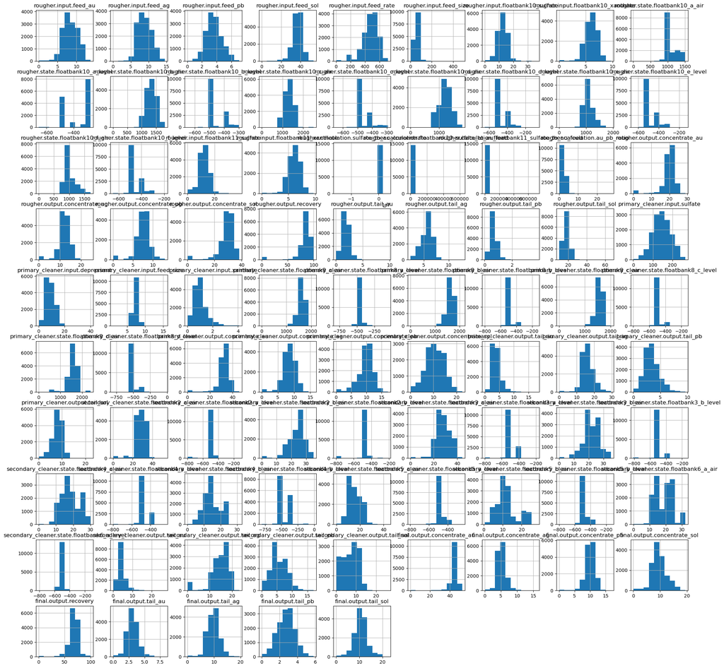

```python
explore_data(df_t)
```

```
Первые 5 строк набора данных:
```

| date | rougher.input.feed_au | rougher.input.feed_ag | rougher.input.feed_pb | rougher.input.feed_sol | rougher.input.feed_rate | rougher.input.feed_size | rougher.input.floatbank10_sulfate | rougher.input.floatbank10_xanthate | rougher.state.floatbank10_a_air | rougher.state.floatbank10_a_level | ... | secondary_cleaner.state.floatbank4_a_air | secondary_cleaner.state.floatbank4_a_level | secondary_cleaner.state.floatbank4_b_air | secondary_cleaner.state.floatbank4_b_level | secondary_cleaner.state.floatbank5_a_air | secondary_cleaner.state.floatbank5_a_level | secondary_cleaner.state.floatbank5_b_air | secondary_cleaner.state.floatbank5_b_level | secondary_cleaner.state.floatbank6_a_air | secondary_cleaner.state.floatbank6_a_level |
| --- | --- | --- | --- | --- | --- | --- | --- | --- | --- | --- | --- | --- | --- | --- | --- | --- | --- | --- | --- | --- | --- |
| 2017-12-09 14:59:59 | 4.365491 | 6.158718 | 3.875727 | 39.135119 | 555.820208 | 94.544358 | 6.146982 | 9.308612 | 1196.238112 | -299.862743 | ... | 23.018622 | -500.492702 | 20.020205 | -500.220296 | 17.963512 | -499.939490 | 12.990306 | -500.080993 | 19.990336 | -499.191575 |
| 2017-12-09 15:59:59 | 4.362781 | 6.048130 | 3.902537 | 39.713906 | 544.731687 | 123.742430 | 6.210119 | 9.297709 | 1201.904177 | -299.907308 | ... | 23.024963 | -501.153409 | 20.054122 | -500.314711 | 17.979515 | -499.272871 | 12.992404 | -499.976268 | 20.013986 | -500.625471 |
| 2017-12-09 16:59:59 | 5.081681 | 6.082745 | 4.564078 | 37.208683 | 558.155110 | 82.610855 | 7.363824 | 9.003562 | 1200.826926 | -300.124116 | ... | 22.993827 | -501.559663 | 20.029144 | -500.000662 | 18.012723 | -500.024764 | 13.016445 | -500.058432 | 19.973767 | -501.394155 |
| 2017-12-09 17:59:59 | 5.145949 | 6.084374 | 4.768124 | 36.808874 | 539.713765 | 77.984784 | 6.927072 | 8.955597 | 1199.292489 | -299.778385 | ... | 23.032807 | -501.287889 | 19.977466 | -500.159903 | 17.980463 | -500.504602 | 12.949071 | -500.009937 | 20.010332 | -508.337973 |
| 2017-12-09 18:59:59 | 5.735249 | 6.165220 | 4.512346 | 37.810642 | 558.713584 | 86.434874 | 7.823471 | 7.490356 | 1198.005449 | -300.283401 | ... | 23.001911 | -499.947838 | 20.023735 | -499.713680 | 17.990955 | -500.334769 | 13.007523 | -499.968459 | 19.995999 | -499.788805 |

5 rows × 52 columns

```
Информация о наборе данных:
<class 'pandas.core.frame.DataFrame'>
DatetimeIndex: 4860 entries, 2017-12-09 14:59:59 to 2018-08-18 10:59:59
Data columns (total 52 columns):
 #   Column                                      Non-Null Count  Dtype
---  ------                                      --------------  -----
 0   rougher.input.feed_au                       4860 non-null   float64
 1   rougher.input.feed_ag                       4860 non-null   float64
 2   rougher.input.feed_pb                       4832 non-null   float64
 3   rougher.input.feed_sol                      4838 non-null   float64
 4   rougher.input.feed_rate                     4856 non-null   float64
 5   rougher.input.feed_size                     4816 non-null   float64
 6   rougher.input.floatbank10_sulfate           4857 non-null   float64
 7   rougher.input.floatbank10_xanthate          4859 non-null   float64
 8   rougher.state.floatbank10_a_air             4859 non-null   float64
```

[output cut: 45 more lines]

```
None
```

```
Статистические характеристики числовых столбцов:
```

|  | count | mean | std | min | 25% | 50% | 75% | max |
| --- | --- | --- | --- | --- | --- | --- | --- | --- |
| rougher.input.feed_au | 4860.0 | 8.005584 | 1.993590 | 1.000000e-02 | 6.574363 | 7.812923 | 9.556589 | 13.417156 |
| rougher.input.feed_ag | 4860.0 | 8.547348 | 1.958601 | 1.000000e-02 | 6.975898 | 8.179714 | 10.084339 | 14.533698 |
| rougher.input.feed_pb | 4832.0 | 3.579662 | 1.029377 | 1.000000e-02 | 2.903612 | 3.540772 | 4.199847 | 7.142594 |
| rougher.input.feed_sol | 4838.0 | 37.095864 | 4.926284 | 1.000000e-02 | 34.510841 | 37.499761 | 40.461315 | 53.477742 |
| rougher.input.feed_rate | 4856.0 | 490.285103 | 94.371623 | 1.278570e-02 | 434.099695 | 502.118742 | 555.596563 | 702.523396 |
| rougher.input.feed_size | 4816.0 | 59.113400 | 19.125122 | 4.636880e-02 | 47.596984 | 55.509481 | 66.661547 | 363.989699 |
| rougher.input.floatbank10_sulfate | 4857.0 | 12.055735 | 3.407642 | 1.890695e-02 | 9.890429 | 11.997859 | 14.496072 | 30.010759 |
| rougher.input.floatbank10_xanthate | 4859.0 | 6.101308 | 1.042754 | 1.578303e-02 | 5.499808 | 6.099805 | 6.802101 | 9.396928 |
| rougher.state.floatbank10_a_air | 4859.0 | 1108.635895 | 156.493143 | 3.007925e+02 | 999.715729 | 1001.414798 | 1202.837565 | 1521.980372 |
| rougher.state.floatbank10_a_level | 4859.0 | -368.340127 | 91.155929 | -6.005681e+02 | -499.731972 | -300.181367 | -299.961547 | -281.039299 |
| rougher.state.floatbank10_b_air | 4859.0 | 1312.346061 | 159.001709 | 7.676566e+02 | 1199.741605 | 1300.278835 | 1401.691789 | 1802.528564 |
| rougher.state.floatbank10_b_level | 4859.0 | -472.506533 | 49.376824 | -6.499975e+02 | -500.218827 | -499.827934 | -449.925513 | -298.836629 |
| rougher.state.floatbank10_c_air | 4859.0 | 1291.638282 | 180.203670 | 8.315379e+02 | 1152.401989 | 1299.411789 | 1401.933884 | 2498.873242 |
| rougher.state.floatbank10_c_level | 4859.0 | -472.902514 | 47.611728 | -5.526570e+02 | -500.226269 | -499.761855 | -449.662583 | -298.588757 |
| rougher.state.floatbank10_d_air | 4860.0 | 1204.066585 | 184.547737 | 7.062819e+02 | 1061.682494 | 1200.337639 | 1307.300990 | 1801.712957 |
| rougher.state.floatbank10_d_level | 4860.0 | -473.380689 | 47.828848 | -6.481184e+02 | -500.441025 | -499.597033 | -449.938278 | -296.591110 |
| rougher.state.floatbank10_e_air | 4853.0 | 1075.304980 | 159.989533 | 6.952118e+02 | 998.898177 | 1049.897439 | 1199.145824 | 1701.253009 |
| rougher.state.floatbank10_e_level | 4860.0 | -471.465792 | 51.413832 | -5.989261e+02 | -500.266939 | -499.715147 | -449.384744 | -296.129173 |
| rougher.state.floatbank10_f_air | 4860.0 | 1023.769668 | 147.827669 | 5.396339e+02 | 949.042067 | 1000.060464 | 1099.460790 | 1702.383848 |
| rougher.state.floatbank10_f_level | 4860.0 | -471.412834 | 51.838763 | -6.493762e+02 | -500.534825 | -499.537041 | -448.211283 | -286.375117 |
| rougher.input.floatbank11_sulfate | 4852.0 | 11.969074 | 3.456113 | 1.627663e-04 | 9.822314 | 11.995907 | 14.216091 | 30.006511 |
| rougher.input.floatbank11_xanthate | 4814.0 | 6.119323 | 1.049065 | 2.615756e-03 | 5.500412 | 6.101665 | 6.833554 | 9.401928 |
| primary_cleaner.input.sulfate | 4859.0 | 143.201672 | 42.360060 | 7.329299e+00 | 113.293698 | 139.573692 | 170.743180 | 262.531502 |
| primary_cleaner.input.depressant | 4851.0 | 8.692446 | 3.169592 | 0.000000e+00 | 6.042793 | 8.007390 | 10.613209 | 20.052255 |
| primary_cleaner.input.feed_size | 4860.0 | 7.305514 | 0.588602 | 4.970000e+00 | 6.940000 | 7.290000 | 7.630000 | 9.630000 |
| primary_cleaner.input.xanthate | 4817.0 | 1.007577 | 0.494669 | 1.543956e-04 | 0.700367 | 0.908749 | 1.198047 | 3.999060 |
| primary_cleaner.state.floatbank8_a_air | 4859.0 | 1588.387039 | 124.942960 | 3.142412e+02 | 1505.500055 | 1600.364401 | 1696.676142 | 2079.531340 |
| primary_cleaner.state.floatbank8_a_level | 4859.0 | -488.223175 | 36.672631 | -6.534776e+02 | -500.272366 | -499.893821 | -499.369738 | -330.134203 |
| primary_cleaner.state.floatbank8_b_air | 4859.0 | 1589.297134 | 132.102797 | 3.199595e+02 | 1502.105380 | 1600.363829 | 1699.429311 | 1825.491263 |
| primary_cleaner.state.floatbank8_b_level | 4859.0 | -490.255893 | 35.203702 | -7.992608e+02 | -500.422211 | -499.938871 | -499.331088 | -339.751525 |
| primary_cleaner.state.floatbank8_c_air | 4858.0 | 1588.905465 | 132.689236 | 2.735368e+02 | 1501.205202 | 1600.315592 | 1699.483983 | 1847.621932 |
| primary_cleaner.state.floatbank8_c_level | 4859.0 | -489.741555 | 33.650676 | -7.092138e+02 | -500.676713 | -499.894721 | -498.699191 | -290.845404 |
| primary_cleaner.state.floatbank8_d_air | 4858.0 | 1530.287801 | 256.268884 | 1.313217e+02 | 1450.605949 | 1599.224868 | 1698.766720 | 2398.888373 |
| primary_cleaner.state.floatbank8_d_level | 4859.0 | -485.896489 | 43.296128 | -7.997916e+02 | -500.438064 | -499.857201 | -498.747352 | -107.595099 |
| secondary_cleaner.state.floatbank2_a_air | 4734.0 | 29.488451 | 5.357783 | 1.220129e-01 | 25.116334 | 29.954667 | 34.064460 | 48.822781 |
| secondary_cleaner.state.floatbank2_a_level | 4859.0 | -499.504602 | 43.284386 | -7.996064e+02 | -500.215499 | -499.966865 | -499.678638 | -207.038839 |
| secondary_cleaner.state.floatbank2_b_air | 4859.0 | 24.732293 | 5.484220 | 0.000000e+00 | 22.038700 | 26.880506 | 28.045077 | 35.019409 |
| secondary_cleaner.state.floatbank2_b_level | 4859.0 | -499.556727 | 43.619785 | -7.998739e+02 | -500.223223 | -500.010504 | -499.783594 | -216.660814 |
| secondary_cleaner.state.floatbank3_a_air | 4859.0 | 28.896472 | 6.159087 | 1.957942e-17 | 24.979890 | 28.021079 | 33.985458 | 44.011389 |
| secondary_cleaner.state.floatbank3_a_level | 4859.0 | -489.475315 | 51.827314 | -7.995753e+02 | -500.211535 | -499.952220 | -499.525249 | -246.396324 |
| secondary_cleaner.state.floatbank3_b_air | 4859.0 | 22.632725 | 5.456797 | 1.521587e-17 | 19.011791 | 22.969896 | 26.984159 | 35.051488 |
| secondary_cleaner.state.floatbank3_b_level | 4859.0 | -494.765779 | 40.681493 | -7.587644e+02 | -500.120286 | -499.983839 | -499.824376 | -195.458545 |
| secondary_cleaner.state.floatbank4_a_air | 4859.0 | 19.857704 | 5.913105 | 1.079872e-16 | 15.011226 | 19.968066 | 24.988999 | 30.084500 |
| secondary_cleaner.state.floatbank4_a_level | 4859.0 | -488.665140 | 44.392714 | -7.997050e+02 | -500.704004 | -499.892919 | -498.652030 | -383.373053 |
| secondary_cleaner.state.floatbank4_b_air | 4859.0 | 15.570248 | 4.927361 | 2.489718e-17 | 12.021716 | 15.012395 | 19.999489 | 23.988976 |
| secondary_cleaner.state.floatbank4_b_level | 4859.0 | -464.176507 | 65.706994 | -7.998608e+02 | -500.196517 | -499.540776 | -400.302329 | -114.250832 |
| secondary_cleaner.state.floatbank5_a_air | 4859.0 | 16.594103 | 5.724305 | -3.714983e-01 | 11.073822 | 16.631195 | 19.983191 | 33.215996 |
| secondary_cleaner.state.floatbank5_a_level | 4859.0 | -490.815250 | 32.258443 | -7.971425e+02 | -500.483564 | -499.873136 | -498.852815 | -288.963521 |
| secondary_cleaner.state.floatbank5_b_air | 4859.0 | 12.945971 | 5.533176 | 1.358469e+00 | 9.011890 | 11.999417 | 15.004198 | 24.177106 |
| secondary_cleaner.state.floatbank5_b_level | 4859.0 | -489.583564 | 37.084609 | -8.000062e+02 | -500.129913 | -499.955304 | -499.643776 | -141.934397 |
| secondary_cleaner.state.floatbank6_a_air | 4859.0 | 19.053888 | 5.548996 | 1.603862e-01 | 14.963953 | 19.960006 | 24.974583 | 32.028529 |
| secondary_cleaner.state.floatbank6_a_level | 4859.0 | -504.678924 | 38.690186 | -8.097348e+02 | -500.668501 | -500.033769 | -499.460134 | -104.427459 |

```
Число уникальных значений в каждом столбце:
Столбец 'rougher.input.feed_au' содержит 4857 уникальных значений.
Столбец 'rougher.input.feed_ag' содержит 4857 уникальных значений.
Столбец 'rougher.input.feed_pb' содержит 4828 уникальных значений.
Столбец 'rougher.input.feed_sol' содержит 4835 уникальных значений.
Столбец 'rougher.input.feed_rate' содержит 4857 уникальных значений.
Столбец 'rougher.input.feed_size' содержит 4812 уникальных значений.
Столбец 'rougher.input.floatbank10_sulfate' содержит 4858 уникальных значений.
Столбец 'rougher.input.floatbank10_xanthate' содержит 4860 уникальных значений.
Столбец 'rougher.state.floatbank10_a_air' содержит 4860 уникальных значений.
Столбец 'rougher.state.floatbank10_a_level' содержит 4860 уникальных значений.
Столбец 'rougher.state.floatbank10_b_air' содержит 4860 уникальных значений.
Столбец 'rougher.state.floatbank10_b_level' содержит 4860 уникальных значений.
Столбец 'rougher.state.floatbank10_c_air' содержит 4860 уникальных значений.
Столбец 'rougher.state.floatbank10_c_level' содержит 4860 уникальных значений.
Столбец 'rougher.state.floatbank10_d_air' содержит 4860 уникальных значений.
Столбец 'rougher.state.floatbank10_d_level' содержит 4860 уникальных значений.
Столбец 'rougher.state.floatbank10_e_air' содержит 4854 уникальных значений.
Столбец 'rougher.state.floatbank10_e_level' содержит 4860 уникальных значений.
Столбец 'rougher.state.floatbank10_f_air' содержит 4860 уникальных значений.
Столбец 'rougher.state.floatbank10_f_level' содержит 4860 уникальных значений.
Столбец 'rougher.input.floatbank11_sulfate' содержит 4853 уникальных значений.
Столбец 'rougher.input.floatbank11_xanthate' содержит 4811 уникальных значений.
Столбец 'primary_cleaner.input.sulfate' содержит 4860 уникальных значений.
Столбец 'primary_cleaner.input.depressant' содержит 4852 уникальных значений.
Столбец 'primary_cleaner.input.feed_size' содержит 1448 уникальных значений.
Столбец 'primary_cleaner.input.xanthate' содержит 4818 уникальных значений.
Столбец 'primary_cleaner.state.floatbank8_a_air' содержит 4860 уникальных значений.
Столбец 'primary_cleaner.state.floatbank8_a_level' содержит 4860 уникальных значений.
Столбец 'primary_cleaner.state.floatbank8_b_air' содержит 4860 уникальных значений.
Столбец 'primary_cleaner.state.floatbank8_b_level' содержит 4860 уникальных значений.
Столбец 'primary_cleaner.state.floatbank8_c_air' содержит 4859 уникальных значений.
Столбец 'primary_cleaner.state.floatbank8_c_level' содержит 4860 уникальных значений.
Столбец 'primary_cleaner.state.floatbank8_d_air' содержит 4859 уникальных значений.
Столбец 'primary_cleaner.state.floatbank8_d_level' содержит 4860 уникальных значений.
Столбец 'secondary_cleaner.state.floatbank2_a_air' содержит 4735 уникальных значений.
Столбец 'secondary_cleaner.state.floatbank2_a_level' содержит 4860 уникальных значений.
Столбец 'secondary_cleaner.state.floatbank2_b_air' содержит 4830 уникальных значений.
Столбец 'secondary_cleaner.state.floatbank2_b_level' содержит 4860 уникальных значений.
Столбец 'secondary_cleaner.state.floatbank3_a_air' содержит 4845 уникальных значений.
Столбец 'secondary_cleaner.state.floatbank3_a_level' содержит 4860 уникальных значений.
Столбец 'secondary_cleaner.state.floatbank3_b_air' содержит 4832 уникальных значений.
Столбец 'secondary_cleaner.state.floatbank3_b_level' содержит 4860 уникальных значений.
Столбец 'secondary_cleaner.state.floatbank4_a_air' содержит 4856 уникальных значений.
Столбец 'secondary_cleaner.state.floatbank4_a_level' содержит 4860 уникальных значений.
Столбец 'secondary_cleaner.state.floatbank4_b_air' содержит 4853 уникальных значений.
Столбец 'secondary_cleaner.state.floatbank4_b_level' содержит 4860 уникальных значений.
Столбец 'secondary_cleaner.state.floatbank5_a_air' содержит 4860 уникальных значений.
Столбец 'secondary_cleaner.state.floatbank5_a_level' содержит 4860 уникальных значений.
Столбец 'secondary_cleaner.state.floatbank5_b_air' содержит 4860 уникальных значений.
Столбец 'secondary_cleaner.state.floatbank5_b_level' содержит 4860 уникальных значений.
Столбец 'secondary_cleaner.state.floatbank6_a_air' содержит 4860 уникальных значений.
Столбец 'secondary_cleaner.state.floatbank6_a_level' содержит 4860 уникальных значений.

Число значений по категориям в каждом столбце:

Гистограммы всех числовых столбцов:
```

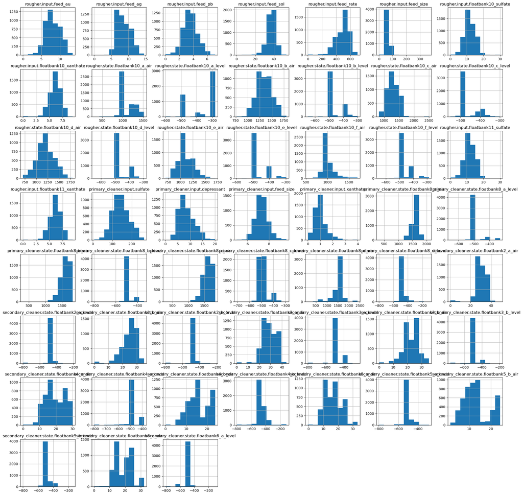

```python
explore_data(df_te)
```

```
Первые 5 строк набора данных:
```

| date | rougher.input.feed_au | rougher.input.feed_ag | rougher.input.feed_pb | rougher.input.feed_sol | rougher.input.feed_rate | rougher.input.feed_size | rougher.input.floatbank10_sulfate | rougher.input.floatbank10_xanthate | rougher.state.floatbank10_a_air | rougher.state.floatbank10_a_level | ... | secondary_cleaner.output.tail_sol | final.output.concentrate_au | final.output.concentrate_ag | final.output.concentrate_pb | final.output.concentrate_sol | final.output.recovery | final.output.tail_au | final.output.tail_ag | final.output.tail_pb | final.output.tail_sol |
| --- | --- | --- | --- | --- | --- | --- | --- | --- | --- | --- | --- | --- | --- | --- | --- | --- | --- | --- | --- | --- | --- |
| 2016-01-15 00:00:00 | 6.486150 | 6.100378 | 2.284912 | 36.808594 | 523.546326 | 55.486599 | 11.986616 | 6.007990 | 999.706909 | -404.066986 | ... | 8.764648 | 42.192020 | 6.055403 | 9.889648 | 5.507324 | 70.541216 | 2.143149 | 10.411962 | 0.895447 | 16.904297 |
| 2016-01-15 01:00:00 | 6.478583 | 6.161113 | 2.266033 | 35.753385 | 525.290581 | 57.278666 | 11.971193 | 6.005766 | 1000.286398 | -400.065196 | ... | 9.001494 | 42.701629 | 6.029369 | 9.968944 | 5.257781 | 69.266198 | 2.224930 | 10.462676 | 0.927452 | 16.634514 |
| 2016-01-15 02:00:00 | 6.362222 | 6.116455 | 2.159622 | 35.971630 | 530.026610 | 57.510649 | 11.920603 | 6.197377 | 999.719565 | -400.074028 | ... | 8.842896 | 42.657501 | 6.055926 | 10.213995 | 5.383759 | 68.116445 | 2.257889 | 10.507046 | 0.953716 | 16.208849 |
| 2016-01-15 03:00:00 | 6.118189 | 6.043309 | 2.037807 | 36.862241 | 542.590390 | 57.792734 | 11.630094 | 6.203177 | 999.814770 | -400.200179 | ... | 9.122857 | 42.689819 | 6.047977 | 9.977019 | 4.858634 | 68.347543 | 2.146849 | 10.422762 | 0.883763 | 16.532835 |
| 2016-01-15 04:00:00 | 5.663707 | 6.060915 | 1.786875 | 34.347666 | 540.531893 | 56.047189 | 10.957755 | 6.198826 | 999.678690 | -399.752729 | ... | 8.871028 | 42.774141 | 6.148599 | 10.142511 | 4.939416 | 66.927016 | 2.055292 | 10.360302 | 0.792826 | 16.525686 |

5 rows × 86 columns

```
Информация о наборе данных:
<class 'pandas.core.frame.DataFrame'>
DatetimeIndex: 19439 entries, 2016-01-15 00:00:00 to 2018-08-18 10:59:59
Data columns (total 86 columns):
 #   Column                                              Non-Null Count  Dtype
---  ------                                              --------------  -----
 0   rougher.input.feed_au                               19439 non-null  float64
 1   rougher.input.feed_ag                               19439 non-null  float64
 2   rougher.input.feed_pb                               19339 non-null  float64
 3   rougher.input.feed_sol                              19340 non-null  float64
 4   rougher.input.feed_rate                             19428 non-null  float64
 5   rougher.input.feed_size                             19294 non-null  float64
 6   rougher.input.floatbank10_sulfate                   19405 non-null  float64
 7   rougher.input.floatbank10_xanthate                  19431 non-null  float64
 8   rougher.state.floatbank10_a_air                     19438 non-null  float64
```

[output cut: 79 more lines]

```
None
```

```
Статистические характеристики числовых столбцов:
```

|  | count | mean | std | min | 25% | 50% | 75% | max |
| --- | --- | --- | --- | --- | --- | --- | --- | --- |
| rougher.input.feed_au | 19439.0 | 8.266097 | 1.955092 | 0.010000 | 6.854384 | 8.125839 | 9.769917 | 13.731330 |
| rougher.input.feed_ag | 19439.0 | 8.794927 | 1.936847 | 0.010000 | 7.237967 | 8.593574 | 10.213771 | 14.596026 |
| rougher.input.feed_pb | 19339.0 | 3.598085 | 1.049486 | 0.010000 | 2.887280 | 3.534895 | 4.244161 | 7.142594 |
| rougher.input.feed_sol | 19340.0 | 36.695114 | 5.145445 | 0.010000 | 34.207799 | 37.202650 | 40.039133 | 53.477742 |
| rougher.input.feed_rate | 19428.0 | 478.320042 | 105.373758 | 0.002986 | 416.525453 | 499.416120 | 550.172183 | 717.508837 |
| ... | ... | ... | ... | ... | ... | ... | ... | ... |
| final.output.recovery | 19439.0 | 67.050208 | 10.125840 | 0.000000 | 63.299712 | 68.172738 | 72.686642 | 100.000000 |
| final.output.tail_au | 19439.0 | 3.042467 | 0.922808 | 0.000000 | 2.461138 | 2.984909 | 3.571351 | 8.245022 |
| final.output.tail_ag | 19438.0 | 9.688589 | 2.328642 | 0.000000 | 8.062878 | 9.743623 | 11.134294 | 19.552149 |
| final.output.tail_pb | 19338.0 | 2.705795 | 0.949077 | 0.000000 | 2.040119 | 2.748730 | 3.333216 | 5.804178 |
| final.output.tail_sol | 19433.0 | 10.583728 | 2.868782 | 0.000000 | 8.938947 | 10.622456 | 12.104271 | 22.317730 |

86 rows × 8 columns

```
Число уникальных значений в каждом столбце:
Столбец 'rougher.input.feed_au' содержит 19409 уникальных значений.
Столбец 'rougher.input.feed_ag' содержит 19409 уникальных значений.
Столбец 'rougher.input.feed_pb' содержит 19301 уникальных значений.
Столбец 'rougher.input.feed_sol' содержит 19293 уникальных значений.
Столбец 'rougher.input.feed_rate' содержит 19429 уникальных значений.
Столбец 'rougher.input.feed_size' содержит 19287 уникальных значений.
Столбец 'rougher.input.floatbank10_sulfate' содержит 19406 уникальных значений.
Столбец 'rougher.input.floatbank10_xanthate' содержит 19432 уникальных значений.
Столбец 'rougher.state.floatbank10_a_air' содержит 19439 уникальных значений.
Столбец 'rougher.state.floatbank10_a_level' содержит 19439 уникальных значений.
Столбец 'rougher.state.floatbank10_b_air' содержит 19439 уникальных значений.
Столбец 'rougher.state.floatbank10_b_level' содержит 19439 уникальных значений.
Столбец 'rougher.state.floatbank10_c_air' содержит 19439 уникальных значений.
Столбец 'rougher.state.floatbank10_c_level' содержит 19439 уникальных значений.
Столбец 'rougher.state.floatbank10_d_air' содержит 19439 уникальных значений.
Столбец 'rougher.state.floatbank10_d_level' содержит 19439 уникальных значений.
Столбец 'rougher.state.floatbank10_e_air' содержит 19004 уникальных значений.
Столбец 'rougher.state.floatbank10_e_level' содержит 19439 уникальных значений.
Столбец 'rougher.state.floatbank10_f_air' содержит 19439 уникальных значений.
Столбец 'rougher.state.floatbank10_f_level' содержит 19438 уникальных значений.
Столбец 'rougher.input.floatbank11_sulfate' содержит 19396 уникальных значений.
Столбец 'rougher.input.floatbank11_xanthate' содержит 18972 уникальных значений.
Столбец 'rougher.calculation.sulfate_to_au_concentrate' содержит 19438 уникальных значений.
Столбец 'rougher.calculation.floatbank10_sulfate_to_au_feed' содержит 19438 уникальных значений.
Столбец 'rougher.calculation.floatbank11_sulfate_to_au_feed' содержит 19438 уникальных значений.
Столбец 'rougher.calculation.au_pb_ratio' содержит 19409 уникальных значений.
Столбец 'rougher.output.concentrate_au' содержит 19015 уникальных значений.
Столбец 'rougher.output.concentrate_ag' содержит 19015 уникальных значений.
Столбец 'rougher.output.concentrate_pb' содержит 18956 уникальных значений.
Столбец 'rougher.output.concentrate_sol' содержит 18665 уникальных значений.
Столбец 'rougher.output.recovery' содержит 19017 уникальных значений.
Столбец 'rougher.output.tail_au' содержит 19399 уникальных значений.
Столбец 'rougher.output.tail_ag' содержит 19398 уникальных значений.
Столбец 'rougher.output.tail_pb' содержит 19409 уникальных значений.
Столбец 'rougher.output.tail_sol' содержит 19272 уникальных значений.
Столбец 'primary_cleaner.input.sulfate' содержит 19416 уникальных значений.
Столбец 'primary_cleaner.input.depressant' содержит 19394 уникальных значений.
Столбец 'primary_cleaner.input.feed_size' содержит 5022 уникальных значений.
Столбец 'primary_cleaner.input.xanthate' содержит 19336 уникальных значений.
```

[output cut: 36 more lines]

```
Столбец 'secondary_cleaner.output.tail_pb' содержит 18563 уникальных значений.
Столбец 'secondary_cleaner.output.tail_sol' содержит 16832 уникальных значений.
Столбец 'final.output.concentrate_au' содержит 19308 уникальных значений.
Столбец 'final.output.concentrate_ag' содержит 19308 уникальных значений.
Столбец 'final.output.concentrate_pb' содержит 19277 уникальных значений.
Столбец 'final.output.concentrate_sol' содержит 19094 уникальных значений.
Столбец 'final.output.recovery' содержит 19235 уникальных значений.
Столбец 'final.output.tail_au' содержит 19329 уникальных значений.
Столбец 'final.output.tail_ag' содержит 19329 уникальных значений.
Столбец 'final.output.tail_pb' содержит 19229 уникальных значений.
Столбец 'final.output.tail_sol' содержит 19323 уникальных значений.

Число значений по категориям в каждом столбце:

Гистограммы всех числовых столбцов:
```

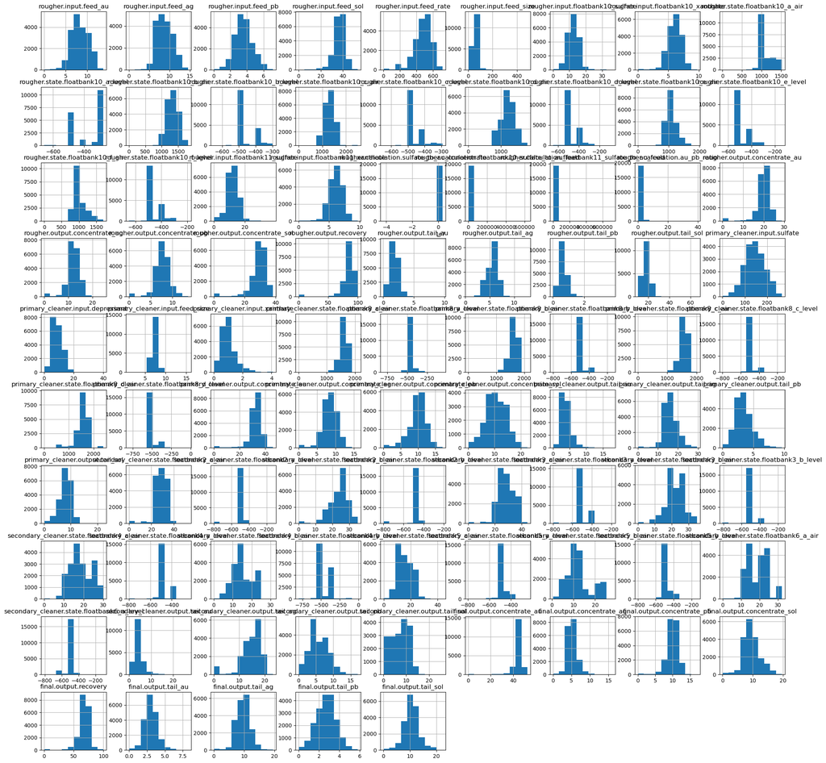

```python
explore_data(df_f)
```

**Комментарий:**

- Во всех 3 наборах прослеживаются неравное количество элементов в столбцах, что может говорить о пропусках
- Про отсальные характеристики данных на этом этапе сложно говорить из-за большого количества столбцов

### Поверка эффективности обогащения

```python
# Получение значений столбцов
recovery_actual = df_t['rougher.output.recovery']
concentrate_au = df_t['rougher.output.concentrate_au']
feed_au = df_t['rougher.input.feed_au']
tail_au = df_t['rougher.output.tail_au']

# Расчет эффективности обогащения
recovery_calculated = ((concentrate_au * (feed_au - tail_au)) / (feed_au * (concentrate_au - tail_au))) * 100

# Вычисление MAE
mae = mean_absolute_error(recovery_actual, recovery_calculated)

print("MAE:", mae)
```

```
MAE: 9.83758577644259e-15
```

**Комментарий:** Значение MAE (Mean Absolute Error) в размере 9.83758577644259e-15, которое очень близко к нулю, говорит о том, что расчеты эффективности обогащения (recovery) на обучающей выборке совпадают практически полностью с фактическими значениями этого признака. Такое небольшое значение MAE указывает на высокую точность расчетов и подтверждает, что эффективность обогащения была рассчитана правильно.

### Признаки, недоступные в тестовой выборке

```python
# Получение списка признаков в обучающей выборке
train_features = df_t.columns.tolist()

# Получение списка признаков в тестовой выборке
test_features = df_te.columns.tolist()

# Определение отсутствующих признаков в тестовой выборке
missing_features = sorted(set(train_features) - set(test_features))

# Вывод отсутствующих признаков
print("Отсутствующие признаки в тестовой выборке:")
for feature in missing_features:
    print(feature)
```

```
Отсутствующие признаки в тестовой выборке:
final.output.concentrate_ag
final.output.concentrate_au
final.output.concentrate_pb
final.output.concentrate_sol
final.output.recovery
final.output.tail_ag
final.output.tail_au
final.output.tail_pb
final.output.tail_sol
primary_cleaner.output.concentrate_ag
primary_cleaner.output.concentrate_au
primary_cleaner.output.concentrate_pb
primary_cleaner.output.concentrate_sol
primary_cleaner.output.tail_ag
primary_cleaner.output.tail_au
primary_cleaner.output.tail_pb
primary_cleaner.output.tail_sol
rougher.calculation.au_pb_ratio
rougher.calculation.floatbank10_sulfate_to_au_feed
rougher.calculation.floatbank11_sulfate_to_au_feed
rougher.calculation.sulfate_to_au_concentrate
rougher.output.concentrate_ag
rougher.output.concentrate_au
rougher.output.concentrate_pb
rougher.output.concentrate_sol
rougher.output.recovery
rougher.output.tail_ag
rougher.output.tail_au
rougher.output.tail_pb
rougher.output.tail_sol
secondary_cleaner.output.tail_ag
secondary_cleaner.output.tail_au
secondary_cleaner.output.tail_pb
secondary_cleaner.output.tail_sol
```

**Комментарий:** В тестовой выборке отсутствуют признаки, связанные с характеристиками продукта после флотации и очистки. В списке отсутствующих признаков перечислены имена признаков, которые относятся к концентрату (concentrate) и отвальным хвостам (tail) различных металлов (ag, au, pb, sol). Также в списке отсутствуют признаки, связанные с вычисленными характеристиками и соотношениями между металлами в процессе обогащения (calculation).

### Предобработка данных

**Проверка на пропуски и дубликаты**

```python
def check_missing_duplicates(df):

    # Сортировка по столбцу 'date'
    df.sort_values('date', inplace=True)

    # Преобразование столбца 'date' в индексы
    #df.set_index('date', inplace=True)

    # Поиск пропусков
    missing_values = df.isnull().sum()
    if missing_values.sum() > 0:
        print("Найдены пропуски:")
        print(missing_values)
    else:
        print("Пропусков не найдено.")

    # Поиск дубликатов
    duplicate_rows = df.duplicated()
    if duplicate_rows.sum() > 0:
        print("Найдены дубликаты:")
        print(df[duplicate_rows])
    else:
        print("Дубликатов не найдено.")

    # Заполнение пропусков методом ближайшего соседа
    df_filled = df.interpolate(method='time')

    # Проверка наличия пропусков после заполнения
    missing_values_filled = df_filled.isnull().sum()
    if missing_values_filled.sum() > 0:
        print("Пропуски после заполнения:")
        print(missing_values_filled)
    else:
        print("Пропуски успешно заполнены.")

    # Обратное преобразование столбца 'date'
    df_filled.reset_index(inplace=True)

    return df_filled
```

```python
df_t = check_missing_duplicates(df_t)
```

```
Найдены пропуски:
rougher.input.feed_au       0
rougher.input.feed_ag       0
rougher.input.feed_pb      72
rougher.input.feed_sol     77
rougher.input.feed_rate     7
                           ..
final.output.recovery       0
final.output.tail_au        0
final.output.tail_ag        1
final.output.tail_pb       75
final.output.tail_sol       5
Length: 86, dtype: int64
Дубликатов не найдено.
Пропуски успешно заполнены.
```

```python
df_te = check_missing_duplicates(df_te)
```

```
Найдены пропуски:
rougher.input.feed_au                           0
rougher.input.feed_ag                           0
rougher.input.feed_pb                          28
rougher.input.feed_sol                         22
rougher.input.feed_rate                         4
rougher.input.feed_size                        44
rougher.input.floatbank10_sulfate               3
rougher.input.floatbank10_xanthate              1
rougher.state.floatbank10_a_air                 1
rougher.state.floatbank10_a_level               1
rougher.state.floatbank10_b_air                 1
rougher.state.floatbank10_b_level               1
rougher.state.floatbank10_c_air                 1
rougher.state.floatbank10_c_level               1
rougher.state.floatbank10_d_air                 0
rougher.state.floatbank10_d_level               0
rougher.state.floatbank10_e_air                 7
rougher.state.floatbank10_e_level               0
rougher.state.floatbank10_f_air                 0
rougher.state.floatbank10_f_level               0
rougher.input.floatbank11_sulfate               8
rougher.input.floatbank11_xanthate             46
primary_cleaner.input.sulfate                   1
primary_cleaner.input.depressant                9
primary_cleaner.input.feed_size                 0
primary_cleaner.input.xanthate                 43
primary_cleaner.state.floatbank8_a_air          1
primary_cleaner.state.floatbank8_a_level        1
primary_cleaner.state.floatbank8_b_air          1
primary_cleaner.state.floatbank8_b_level        1
primary_cleaner.state.floatbank8_c_air          2
primary_cleaner.state.floatbank8_c_level        1
primary_cleaner.state.floatbank8_d_air          2
primary_cleaner.state.floatbank8_d_level        1
secondary_cleaner.state.floatbank2_a_air      126
secondary_cleaner.state.floatbank2_a_level      1
secondary_cleaner.state.floatbank2_b_air        1
secondary_cleaner.state.floatbank2_b_level      1
secondary_cleaner.state.floatbank3_a_air        1
secondary_cleaner.state.floatbank3_a_level      1
secondary_cleaner.state.floatbank3_b_air        1
secondary_cleaner.state.floatbank3_b_level      1
secondary_cleaner.state.floatbank4_a_air        1
secondary_cleaner.state.floatbank4_a_level      1
secondary_cleaner.state.floatbank4_b_air        1
secondary_cleaner.state.floatbank4_b_level      1
secondary_cleaner.state.floatbank5_a_air        1
secondary_cleaner.state.floatbank5_a_level      1
secondary_cleaner.state.floatbank5_b_air        1
secondary_cleaner.state.floatbank5_b_level      1
secondary_cleaner.state.floatbank6_a_air        1
secondary_cleaner.state.floatbank6_a_level      1
dtype: int64
Дубликатов не найдено.
Пропуски успешно заполнены.
```

```python
df_f = check_missing_duplicates(df_f)
```

```
Найдены пропуски:
rougher.input.feed_au        0
rougher.input.feed_ag        0
rougher.input.feed_pb      100
rougher.input.feed_sol      99
rougher.input.feed_rate     11
                          ...
final.output.recovery        0
final.output.tail_au         0
final.output.tail_ag         1
final.output.tail_pb       101
final.output.tail_sol        6
Length: 86, dtype: int64
Дубликатов не найдено.
Пропуски успешно заполнены.
```

**Комментарий:** Метод заполнения пропусков df.interpolate(method='time') был выбран исходя из того, что данные индексируются датой и временем получения информации (признак 'date'), и соседние по времени параметры часто похожи.

interpolate(method='time') использует интерполяцию на основе временных значений для заполнения пропущенных данных. Он учитывает временные различия между наблюдениями и использует ближайшие доступные значения во времени для предсказания пропущенных значений

**Проверка на выбросы**

```python
def detect_and_print_outliers(df, threshold=3):
    final_i = None
    outliers = {}

    for column in df.columns:
        if pd.api.types.is_numeric_dtype(df[column]):
            total_rows = df[column].copy().shape[0]
            q1 = df[column].quantile(0.25)
            q3 = df[column].quantile(0.75)
            iqr = q3 - q1
            lower_bound = q1 - threshold * iqr
            upper_bound = q3 + threshold * iqr

            column_outliers = df[(df[column] < lower_bound) | (df[column] > upper_bound)]
            num_outliers = column_outliers.shape[0]

            outlier_ratio = (num_outliers / total_rows) * 100

            outliers[column] = {
                'num_outliers': num_outliers,
                'outlier_ratio': outlier_ratio
            }

    result_df = pd.DataFrame(outliers).T
    result_df.index.name = 'Столбец'
    result_df.columns = ['Количество выбросов', 'Доля выбросов (%)']

    result_df = result_df.sort_values('Доля выбросов (%)', ascending=False)

    # Установка опции для отображения всех строк
    pd.set_option('display.max_rows', 86)

    display(result_df)
```

```python
detect_and_print_outliers(df_t, threshold=3)
```

| Столбец | Количество выбросов | Доля выбросов (%) |
| --- | --- | --- |
| secondary_cleaner.state.floatbank5_b_level | 3642.0 | 24.981137 |
| secondary_cleaner.state.floatbank4_a_level | 3583.0 | 24.576446 |
| secondary_cleaner.state.floatbank3_a_level | 3496.0 | 23.979697 |
| secondary_cleaner.state.floatbank5_a_level | 3418.0 | 23.444681 |
| primary_cleaner.state.floatbank8_d_level | 2968.0 | 20.358049 |
| secondary_cleaner.state.floatbank3_b_level | 2634.0 | 18.067083 |
| primary_cleaner.state.floatbank8_c_level | 2588.0 | 17.751560 |
| primary_cleaner.state.floatbank8_b_level | 2529.0 | 17.346869 |
| secondary_cleaner.state.floatbank2_a_level | 2324.0 | 15.940737 |
| secondary_cleaner.state.floatbank6_a_level | 2003.0 | 13.738940 |
| secondary_cleaner.state.floatbank2_b_level | 1936.0 | 13.279374 |
| primary_cleaner.state.floatbank8_a_level | 1877.0 | 12.874683 |
| primary_cleaner.state.floatbank8_d_air | 748.0 | 5.130667 |
| rougher.output.concentrate_sol | 480.0 | 3.292407 |
| rougher.output.concentrate_au | 479.0 | 3.285548 |
| rougher.output.recovery | 465.0 | 3.189519 |
| final.output.concentrate_au | 455.0 | 3.120927 |
| rougher.output.concentrate_pb | 402.0 | 2.757391 |
| rougher.output.concentrate_ag | 400.0 | 2.743672 |
| primary_cleaner.output.concentrate_au | 397.0 | 2.723095 |
| rougher.calculation.floatbank10_sulfate_to_au_feed | 326.0 | 2.236093 |
| secondary_cleaner.output.tail_au | 285.0 | 1.954867 |
| primary_cleaner.output.concentrate_pb | 220.0 | 1.509020 |
| final.output.recovery | 203.0 | 1.392414 |
| rougher.calculation.sulfate_to_au_concentrate | 194.0 | 1.330681 |
| rougher.calculation.floatbank11_sulfate_to_au_feed | 182.0 | 1.248371 |
| rougher.input.feed_size | 181.0 | 1.241512 |
| final.output.concentrate_pb | 152.0 | 1.042596 |
| rougher.input.floatbank11_xanthate | 151.0 | 1.035736 |
| primary_cleaner.output.tail_au | 138.0 | 0.946567 |

[output cut: 56 more lines]